# Non-disclosive federated exposome data analysis with DataSHIELD and Bioconductor

Xavier Escribà Montagut and Juan R. Gonzalez

Bioinformatics Research Group in Epidemiolgy (BRGE), Barcelona Insitute for Global Health (ISGlobal)

xavier.escriba@isglobal.org  
juanr.gonzalez@isglobal.org

2020-11-04

#### Package

dsExposome 0.1.0, dsExposomeClient 0.1.0

# 1 Introduction

Sharing data across studies that are subject to confidentiality and must comply with data protection regulations is a challenging task. [DataSHIELD](http://www.datashield.ac.uk/) is a software solution for secure biomedicine collaboration that allows privacy-protected data analysis of federated databases. It enables the remote and non-disclosive analysis of sensitive research data, and has been developed under several EC projects (BioSHaRE-EU, InterConnect, LifeCycle, EUCAN-Connect). So far, DataSHIELD includes an extensive set of disclosure-protected functions for data manipulation, exploratory data analytics, generalised linear modelling and data visualizations. Here, we have extend DataSHIELD tools by incorporating new functionalities to deal with exposome data visualization and association analysis. We also illustrate how to integrate omics information with exposome data.

[Opal](http://opaldoc.obiba.org/en/latest/) is [OBiBa](https://www.obiba.org/)’s core database application for epidemiological studies. Participant data, collected by questionnaires, medical instruments, sensors, administrative databases etc. can be integrated and stored in a central data repository under a uniform model. Opal is a web application that can import, process, copy data and has advanced features for cataloging the data (fully described, annotatted and searchable data dictionaries). Opal is typically used in a research center to analyze the data acquired at assessment centres. Its ultimate purpose is to achieve seamless data-sharing among epidemiological studies. Opal is the reference implementation of the DataSHIELD infrastructure.

Developing and implementing new algorithms to perform advanced data analyses under DataSHIELD framework is a current active line of research. However, the analysis of big data within DataSHIELD has some limitations. Some of them are related to how data is managed in the Opal’s database and others are related to how to perform statistical analyses of big data within the R environment. Opal databases are for general purpose and do not properly manage large amounts of information and, second, it requires moving data from original repositories into Opal which is inefficient (this is a time, CPU and memory consuming operation) and is difficult to maintain when data are updated. We have recently overcome the problem related to DataSHIELD big data management by developing a new data infrastructure within Opal: [the resources](https://isglobal-brge.github.io/resource_bookdown/resources.html). In this [bookdown](https://isglobal-brge.github.io) the reader can learn a bit more about Opal, DataSHIELD and other releated issues.

This new infrastructure allow us, among others, the analysis of exposome data since we can define a resource as an `ExposomeSet` an specific method to [encapsulate exposome data](https://www.bioconductor.org/packages/release/bioc/vignettes/rexposome/inst/doc/exposome_data_analysis.html)) in R.

For those who are not familiar with Opal servers and do not know how to create this infrastructure, we recommend to read [this section](https://isglobal-brge.github.io/resource_bookdown/tips-and-tricks.html) from our bookdown.

## 1.1 Exposome data in a demo Opal server

We have created an [Opal demo server](https://opal-demo.obiba.org/) that contains different projects, including one called EXPOSOME, as we can see in the next figure

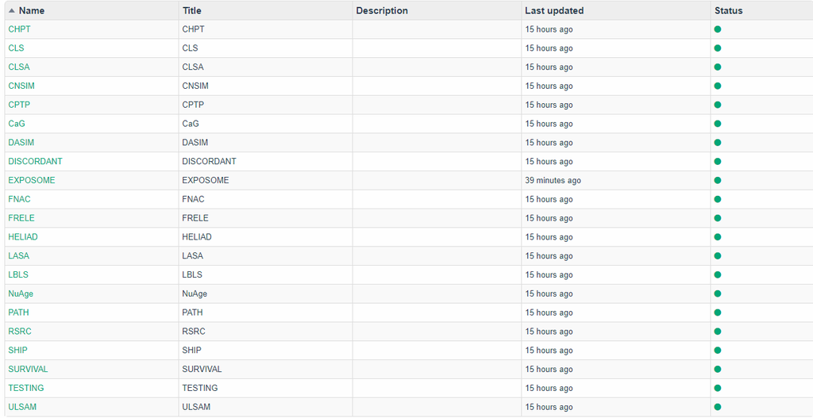

Opal projects in our Opal demo server

The Opal server can be accessed with the credentials:

- username: `administrator`
- password: `password`

The EXPOSOME project contains 4 resources. One `ExposomeSet` object and three other .csv files containing required data for exposome studies: exposome data, exposome annotation and phenotype information.

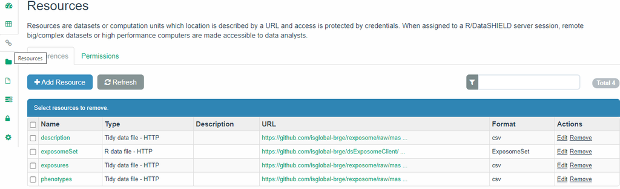

Resources available in the EXPOSOME Opal project

Therefore, we will assume that the user will have either an `ExposomeSet` object or different text/Excel files having exposome data. Next, we illustrate how to perform the main analyses using `ds.Exposome` and `ds.ExposomeClient` packages.

## 1.2 Loading the Exposome Set

An exposome dataset is made up from [three different tables](https://www.bioconductor.org/packages/release/bioc/vignettes/rexposome/inst/doc/exposome_data_analysis.html#data-format). In order to be studied, this three tables need to be coerced into a R object of class `ExposomeSet`, for that reason an exposome dataset can be available on a server as three tables or as a resource.

### 1.2.1 From tables to `ExposomeSet`

To coerce the three tables that make the exposome dataset into an `ExposomeSet` R object, the tables have to be loaded inside the same study server. On this example, the tables are on the demo Opal server as resources, which means they have to be loaded on the study server and be coerced as data frames; for more information read the [resourcer](https://cran.r-project.org/web/packages/resourcer/index.html) package documentation.

```r
library(dsBaseClient)
library(dsExposomeClient)
library(DSOpal)

builder <- newDSLoginBuilder()
builder$append(server = "server1", url = "https://opal-demo.obiba.org/",
               user = "administrator", password = "password",
               driver = "OpalDriver")
logindata <- builder$build()
conns <- datashield.login(logins = logindata)

datashield.assign.resource(conns, symbol = 'description', resource = list(server1 = 'EXPOSOME.description'))
ds.class('description')
```

```
$server1
[1] "TidyFileResourceClient" "FileResourceClient"     "ResourceClient"
[4] "R6"
```

```r
datashield.assign.expr(conns, symbol = "description", expr = quote(as.resource.data.frame(description)))
ds.class('description')
```

```
$server1
[1] "spec_tbl_df" "tbl_df"      "tbl"         "data.frame"
```

```r
datashield.assign.resource(conns, symbol = 'exposures', resource = list(server1 = 'EXPOSOME.exposures'))
datashield.assign.expr(conns, symbol = "exposures", expr = quote(as.resource.data.frame(exposures)))

datashield.assign.resource(conns, symbol = 'phenotypes', resource = list(server1 = 'EXPOSOME.phenotypes'))
datashield.assign.expr(conns, symbol = "phenotypes", expr = quote(as.resource.data.frame(phenotypes)))

ds.ls()
```

```
$server1
$server1$environment.searched
[1] "R_GlobalEnv"

$server1$objects.found
[1] "description" "exposures"   "phenotypes"
```

If the tables are on the Opal server as tables instead of resources, the lines after the `datashield.login` would look like this

```r
# Don't run this code, the tables are not on the demo Opal server, it's just for demostration purposes
datashield.assign.table(conns, symbol = 'description', table = list(server1 = 'EXPOSOME.description_table'))

# Repeat for the other two tables
```

When there are tables on the Opal server they can be directly loaded to the study server as data frames, there is no need to perform the `as.data.frame` assignation.

To coerce the three tables to the `ExposomeSet` object, the `dsExposomeClient` library has the `ds.loadExposome()` function, which takes as input parameters the names of the tables on the study server among some further configuration options, refer to the function documentation for more information.

```r
ds.loadExposome("exposures", "description", "phenotypes", "idnum", "idnum", "Exposure", "Family", 5, FALSE, "exposome_object")
ds.class("exposome_object")
```

```
$server1
[1] "ExposomeSet"
attr(,"package")
[1] "rexposome"
```

### 1.2.2 From resource to `ExposomeSet`

When there’s an `ExposomeSet` resource available, it just needs to be loaded into the study server

```r
datashield.assign.resource(conns, symbol = 'exposome_resource', resource = list(server1 = 'EXPOSOME.exposomeSet'))

ds.ls()
```

```
$server1
$server1$environment.searched
[1] "R_GlobalEnv"

$server1$objects.found
[1] "description"       "exposome_object"   "exposome_resource"
[4] "exposures"         "phenotypes"
```

```r
ds.class("exposome_resource")
```

```
$server1
[1] "RDataFileResourceClient" "FileResourceClient"
[3] "ResourceClient"          "R6"
```

Once on the study server, the resource has to be coerced into an R object

```r
datashield.assign.expr(conns, symbol = "exposome_resource", expr = quote(as.resource.object(exposome_resource)))
ds.class("exposome_resource")
```

```
$server1
[1] "ExposomeSet"
attr(,"package")
[1] "rexposome"
```

## 1.3 Exploring the loaded dataset

Once the Exposome datasets are loaded on the study servers, some simple functions can be used to have some understanding of what the dataset contains. Those correspond to the name of the exposures, the names of the families of the exposures and the name of the phenotypes.

### 1.3.1 Family names

To get the names of the families of exposures present on the exposome set, there’s the `ds.familyNames` function, it can take the parameter `by.exposure = TRUE` to list the family names and the exposures that contain each family.

```r
ds.familyNames("exposome_object")
```

```
$server1
 [1] "Air Pollutants"    "Metals"            "PBDEs"
 [4] "Organochlorines"   "Bisphenol A"       "Water Pollutants"
 [7] "Built Environment" "Cotinine"          "Home Environment"
[10] "Phthalates"        "Noise"             "PFOAs"
[13] "Temperature"
```

```r
head(ds.familyNames("exposome_object", TRUE)$server1)
```

```
         AbsPM25               As           BDE100           BDE138
"Air Pollutants"         "Metals"          "PBDEs"          "PBDEs"
          BDE153           BDE154
         "PBDEs"          "PBDEs"
```

### 1.3.2 Exposures and phenotypes names

To get the names of the exposures or phenotypes (or both combined) there’s the function `ds.exposome_variables`, it takes as argument `exposures`, `phenotypes` or `all` to retrieve the desired names.

```r
head(ds.exposome_variables("exposome_object" , "exposures", conns)$server1)
```

```
[1] "AbsPM25" "As"      "BDE100"  "BDE138"  "BDE153"  "BDE154"
```

```r
ds.exposome_variables("exposome_object" , "phenotypes", conns)
```

```
$server1
[1] "whistling_chest" "flu"             "rhinitis"        "wheezing"
[5] "birthdate"       "sex"             "age"             "cbmi"
[9] "blood_pre"
```

### 1.3.3 Summary of variables

Non-disclosive descriptive statistics can be obtained from the exposome dataset, the function `ds.exposome_summary` is in charge of that. It can obtain descriptive statistics from numeric and factor variables of the exposome dataset (both from exposures and phenotypes).

```r
# Numerical variable
ds.exposome_summary("exposome_object", "PM25", conns)
```

```
$server1
$server1$class
[1] "numeric"

$server1$length
[1] 109

$server1$`quantiles & mean`
      5%      10%      25%      50%      75%      90%      95%     Mean
1.093217 1.132021 1.146654 1.171904 1.181451 1.202192 1.216758 1.165488
```

```r
# Factor variable
ds.exposome_summary("exposome_object", "flu", conns)
```

```
$server1
$server1$class
[1] "character"

$server1$length
[1] 109
```

### 1.3.4 Missing data

The number of missing data on each exposure and on each phenotype can be found by using the function `ds.tableMissings`. This function returns a vector with the amount of missing data in each exposure or phenotype. The argument `set` indicates if the number of missing values is counted on exposures or phenotypes. The argument `output` indicates if it is shown as counts (`output="n"`) or as percentage (`output="p"`).

```r
ds.tableMissings("exposome_object", set = "exposures")
```

```
$server1
        Dens         Temp         Conn      AbsPM25           NO          NO2
           0            0            1            2            2            2
         NOx         PM10       PM10Cu       PM10Fe        PM10K       PM10Ni
           2            2            2            2            2            2
       PM10S       PM10SI       PM10Zn         PM25       PM25CU       PM25FE
           2            2            2            2            2            2
       PM25K       PM25Ni        PM25S       PM25Sl       PM25Zn     PMcoarse
           2            2            2            2            2            2
     Benzene        PM25V          ETS G_pesticides          Gas         BTHM
           3            3            5            5            5            6
       CHCl3 H_pesticides      Noise_d      Noise_n          THM     Cotinine
           6            6            6            6            6            7
        bHCH          DDE          DDT          HCB       PCB118       PCB138
          13           13           13           13           13           13
      PCB153       PCB180          BPA           As           Cs           Mo
          13           13           21           24           24           24
          Ni           Tl           Zn           Hg           Cd           Sb
          24           24           24           27           28           30
       Green           Cu        PM10V           Se         MBzP        MEHHP
          31           40           41           45           46           46
        MEHP        MEOHP          MEP         MiBP         MnBP     X5cxMEPP
          46           46           46           46           46           46
          Co        PFHxS         PFNA         PFOA         PFOS    X7OHMMeOP
          47           48           48           48           48           49
          Pb     X2cxMMHP       BDE100       BDE138       BDE153       BDE154
          59           64           76           76           76           76
       BDE17       BDE183       BDE190       BDE209        BDE28        BDE47
          76           76           76           76           76           76
       BDE66        BDE71        BDE85        BDE99
          76           76           76           76
```

```r
ds.tableMissings("exposome_object", set = "phenotypes")
```

```
$server1
whistling_chest             flu        rhinitis        wheezing             sex
              0               0               0               0               0
            age            cbmi       blood_pre       birthdate
              0               0               2               3
```

Optionally, there’s also the `ds.plotMissings` function which returns a `ggplot` object with a barplot of missings for exposures or phenotypes, there’s the option of displaying the percentage of missings as well as total counts, check the function documentation for further information.

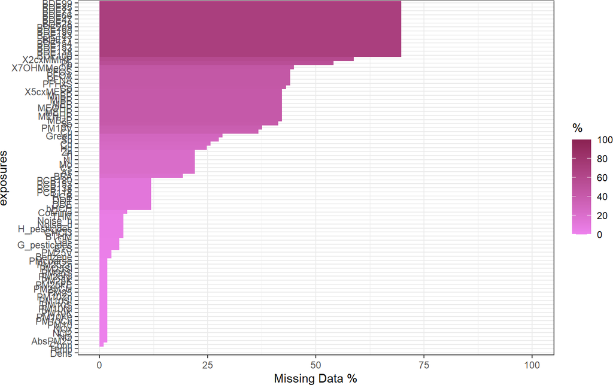

```r
ds.plotMissings("exposome_object", "exposures", "p")
```

Please note that since this function call returns a `ggplot` object, it can be plotted properly to avoid squished Y axis when there are lots of exposures, read the [official documentation](https://ggplot2.tidyverse.org/reference/ggsave.html) for information on how to do that.

### 1.3.5 Exposures Normality

Most of the test done in *exposome* analysis requires that the exposures must follow a normal distribution. The function `ds.normalityTest` performs a test on each exposure for normality behaviour. The result is a `data.frame` with the exposures’ names, a flag `TRUE`/`FALSE` for normality and the p-value obtained from the *Shapiro-Wilk* Normality Test (if the p-value is under the threshold, then the exposure is not normal).

```r
nm <- ds.normalityTest("exposome_object")
table(nm$server1$normality)
```

```
FALSE  TRUE
   55    29
```

So, the exposures that do not follow a normal distribution are:

```r
nm$server1$exposure[!nm$server1$normality]
```

```
 [1] "DDT"      "PM10SI"   "PM25K"    "PM25Sl"   "PCB118"   "Tl"
 [7] "PM10V"    "PM25Zn"   "PM25FE"   "PM10K"    "BDE17"    "PM25"
[13] "PMcoarse" "PM10"     "BPA"      "Green"    "NO2"      "Cs"
[19] "PFNA"     "PCB153"   "PM25CU"   "MEOHP"    "Cu"       "HCB"
[25] "MEHHP"    "DDE"      "BDE190"   "bHCH"     "PM10Zn"   "MnBP"
[31] "NO"       "NOx"      "PM10S"    "MEHP"     "PCB138"   "Zn"
[37] "X2cxMMHP" "PCB180"   "PFOA"     "Cotinine" "PM25S"    "Co"
[43] "Conn"     "PM25Ni"   "PFHxS"    "PM10Ni"   "Cd"       "Dens"
[49] "Se"       "X5cxMEPP" "BDE183"   "BDE28"    "Sb"       "BDE138"
[55] "PM25V"
```

The `ds.normalityTest` function has some extra input arguments to tune the normality test, check the function documentation for further information.

The exposures can be visualized using non-disclosive histograms to see their distribution along their *Shapiro-Wilk* Normality Test p-value.

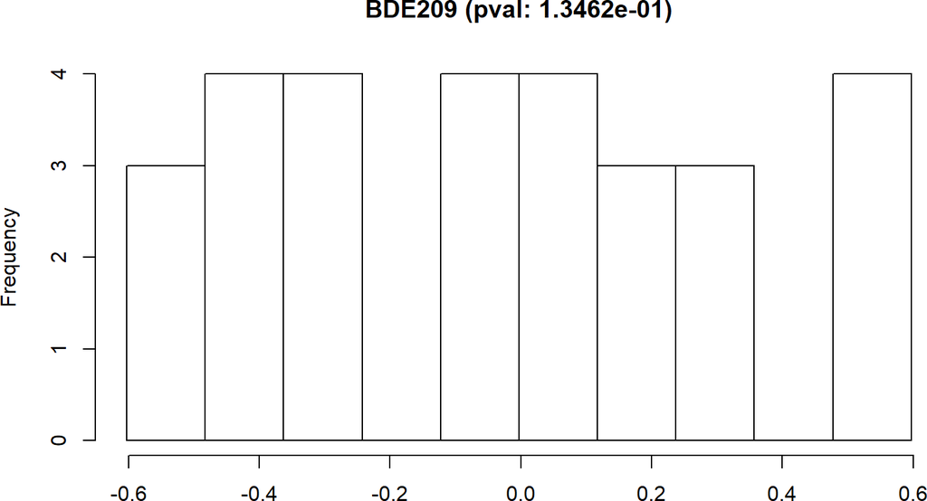

```r
ds.exposure_histogram("exposome_object", "BDE209")
```

If the selected exposure is not following a normal distribution, the function `ds.exposure_histogram` accepts the argument `show.trans` to visualize the raw data histogram plus three typical transformations (`exp`, `log` and `sqrt`), the *Shapiro-Wilk* Normality Test p-value is shown for all the transformations.

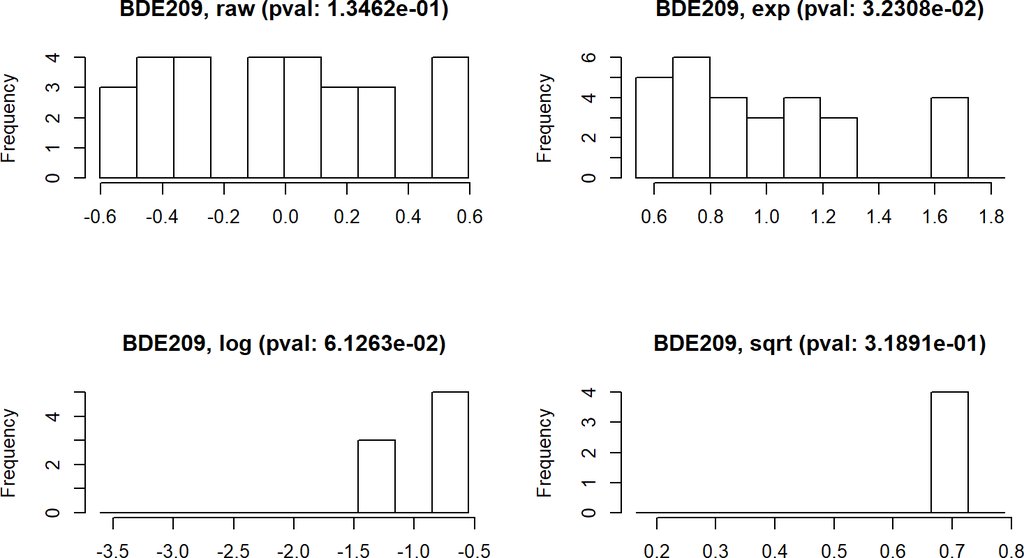

```r
ds.exposure_histogram("exposome_object", "BDE209", TRUE)
```

### 1.3.6 Exposures Behaviour

We can get a snapshot of the behaviour of the full exposome using the `ds.plotFamily` function. This function draws a mosaic of boxplots with all the numeric families of exposures, it can also plot single families and perform grouping inside of them. This function makes use of the `ggplot2` library to generate the plots. Future plans include displaying non-disclosive plots for non-numeric families.

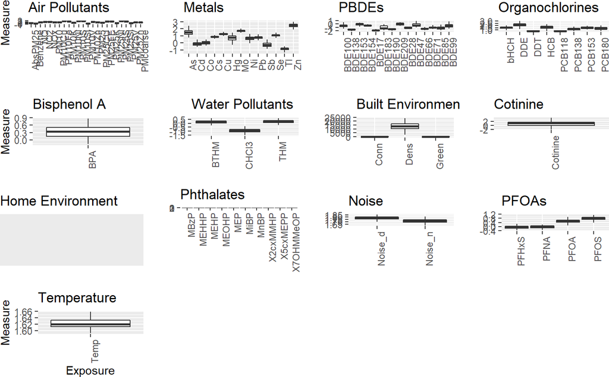

```r
ds.plotFamily("exposome_object", family = "all")
```

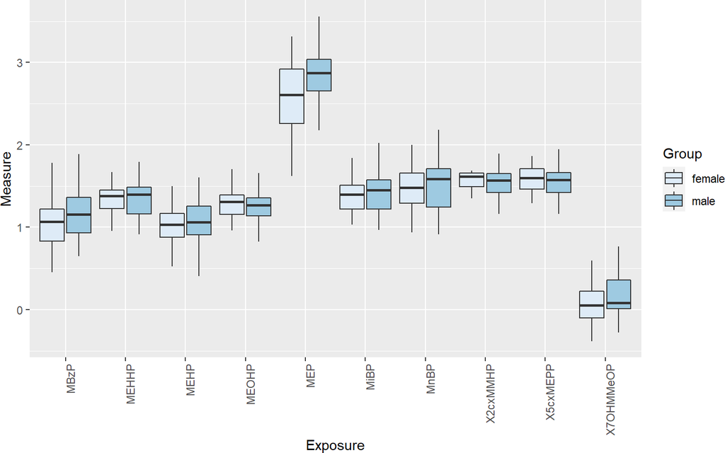

```r
ds.plotFamily("exposome_object", family = "Phthalates", group = "sex")
```

```r
ds.plotFamily("exposome_object", family = "Phthalates", group = "sex", group2 = "rhinitis")
```

[output not shown]

## 1.4 Exposures Imputation

The missings of an exposome dataset can be imputed using the `ds.imputation` function, which calls the rexposome function `imputation` on the study server. Refer to the documentation of rexposome for details about the imputation procedures.

```r
ds.imputation("exposome_object", "exposome_object_imputed")
```

## 1.5 Performing an ExWAS

When the `ExposomeSet` object is on the study the server, the function `ds.exwas` is in charge of performing the ExWAS. As an example let’s present a situation where each exposition has to be associated to the `blood_pre` phenotype using the phenotype `sex` as a covariate. This study would be done as follows

```r
exwas_results <- ds.exwas("blood_pre ~ sex", "exposome_object", "gaussian")
head(exwas_results$exwas_results)
```

```
  exposure         family coefficient      minE      maxE      p.value
1  AbsPM25 Air Pollutants  20.2567443 11.532500 28.980989 5.343657e-06
2       As         Metals   0.5049329 -1.637091  2.646956 6.440695e-01
3   BDE100          PBDEs  -1.4684745 -5.073223  2.136273 4.246181e-01
4   BDE138          PBDEs   1.2819339 -4.872401  7.436269 6.830857e-01
5   BDE153          PBDEs   2.8699183 -1.252769  6.992606 1.724462e-01
6   BDE154          PBDEs   0.1317781 -5.381815  5.645371 9.626373e-01
```

The model is inputted as a string, where the left side term is the objective phenotype, and the right term are the covariates, in the case of wanting more covariates proceed as: `objective ~ cov1 + cov2 + ... + covN`. It’s important noting that if the output family (third argument) does not match the objective family, the ExWAS will fail (Example: The objective family is `binomial` and the user sets it to `gaussian`).

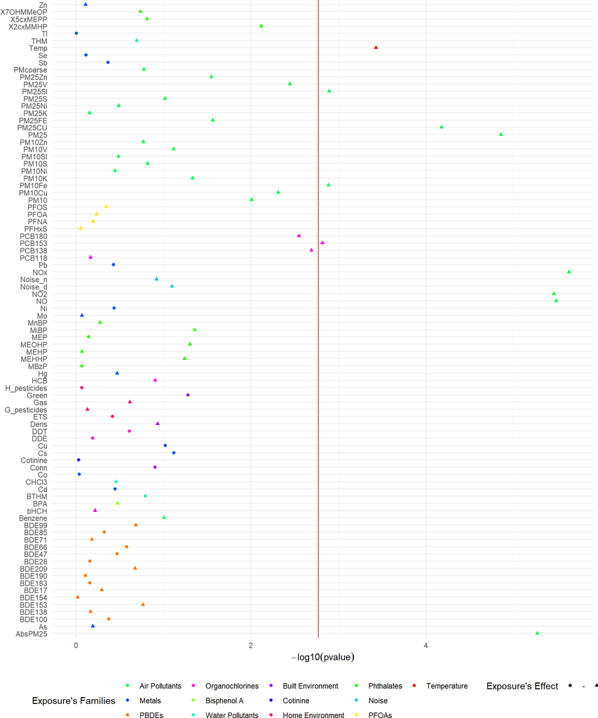

```r
ds.plotExwas(exwas_results, "manhattan")
```

Also, a plot for the effects of a given model can be obtained with:

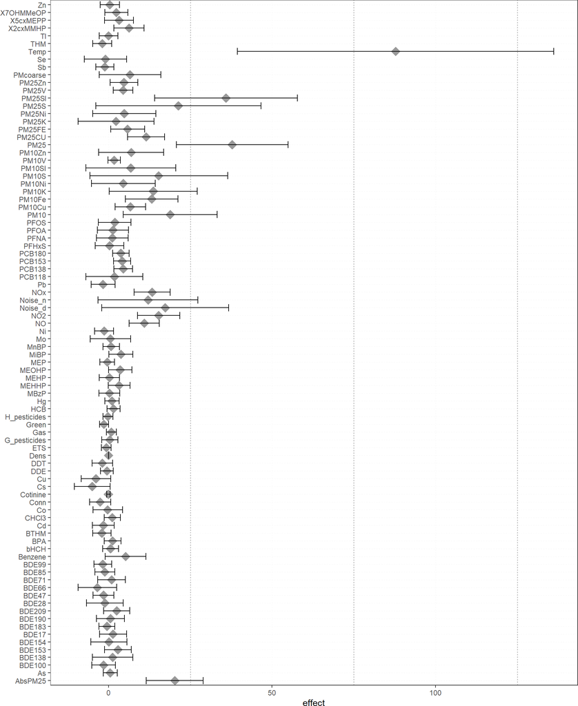

```r
ds.plotExwas(exwas_results, "effect")
```

## 1.6 Exposures PCA

A PCA can be performed on the exposures of the exposome dataset. To do so, there’s the `ds.exposome_pca`. The exposures should be standardized in order to perform the PCA properly, to do so, there’s the arguments `standar` and `method`, which standardize the Exposome Set before performing the PCA following the specified `method`. The available methods are `normal` (default method), which scales the exposures using the mean as the center and the standard variation as dispersion; the `robust` method, which uses the median and median absolute deviation respectively; and, `interquartile range`, which uses the median as the center and the coeficient between the interquartile range of the exposure and the normal range between the percentile 75 and 25 as variance. It is important noting that this function is sensitive to be disclosive, specially for very rectangular data frames (similar number of variables as individuals). To illustrate this problem, let’s try to perform a PCA on the whole exposures test data.

```r
ds.exposome_pca("exposome_object", standar = TRUE)
```

```
Error: There are some DataSHIELD errors, list them with datashield.errors()
```

If that is the case, one option is to reduce the families of exposures of the Exposome Set. The `ds.exposome_pca` function has the argument `fam` to select the families to subset the Exposome Set to perform the PCA.

```r
ds.exposome_pca("exposome_object", fam = c("Metals", "Noise"), standar = TRUE)
```

The PCA function saves the results on the study server to prevent any dislosures, the default variable they take is called `"ds.exposome_pca.Results"`, which has to be passed to the visualization function. To visualize the results of the PCA there is the function `ds.exposome_pca_plot`, this function relies on the visualization methods already implemented on `rexposome` for the PCA analysis, it does it however on a non-disclosive way, by passing the scatter plot points through an anonimization process, hence the arguments `k`, `method` and `noise`. The visualization is controlled with the `set` argument, which takes `"all"` (mosaic of plots of the PCA), `"exposures"` (plot of the exposures space on the first two principal components, color coded by family), `"samples"` (plot of the individuals space on the first two principal components, this plot can take the `phenotype` argument to color code the individuals by phenotypes), `"variance"` and `"variance_explained"`, the two variance plots are quite self explanatory, the color code on the `"variance"` highlights the first two principal components as they are the ones shown on the other drawings.

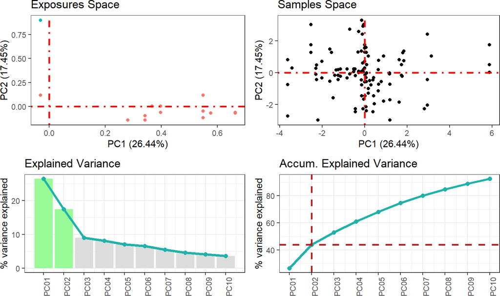

```r
ds.exposome_pca_plot("ds.exposome_pca.Results", set = "all", method = 1, k = 3, noise = 5)
```

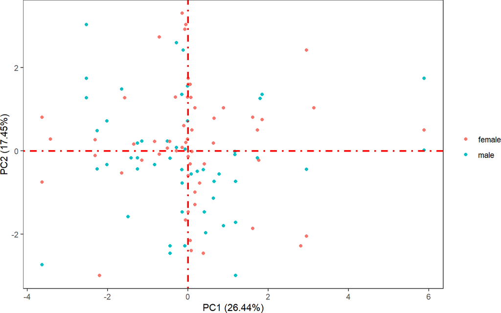

```r
ds.exposome_pca_plot("ds.exposome_pca.Results", set = "samples", phenotype = "sex", method = 1, k = 3, noise = 5)
```

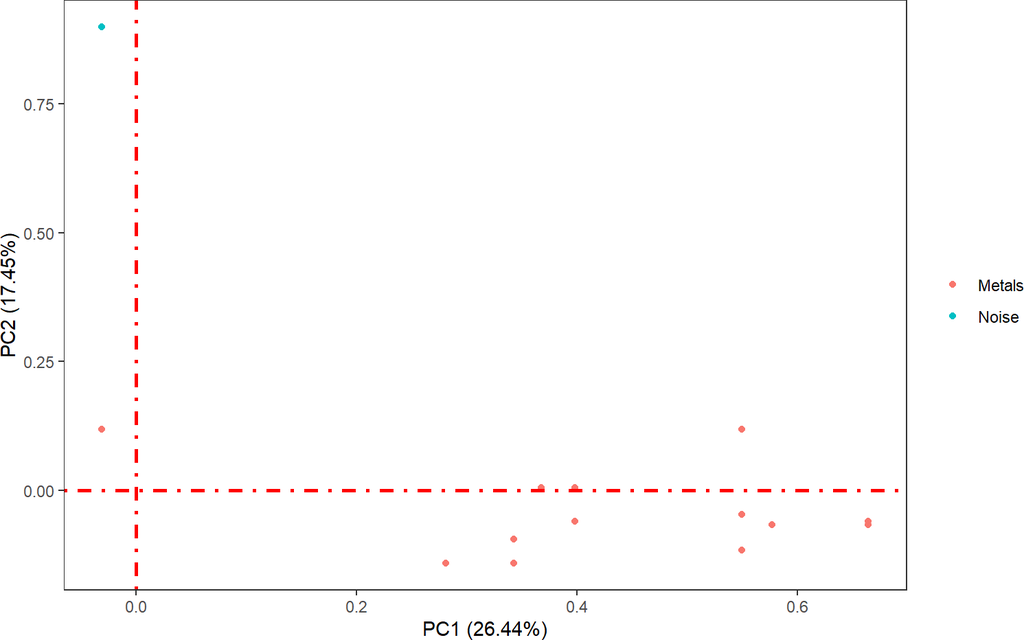

```r
ds.exposome_pca_plot("ds.exposome_pca.Results", set = "exposures", method = 1, k = 3, noise = 5)
```

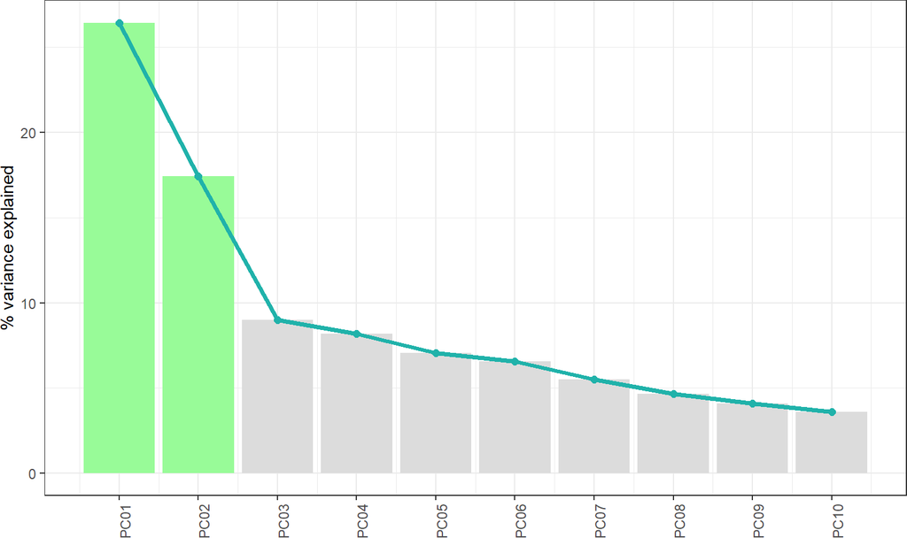

```r
ds.exposome_pca_plot("ds.exposome_pca.Results", set = "variance", method = 1, k = 3, noise = 5)
```

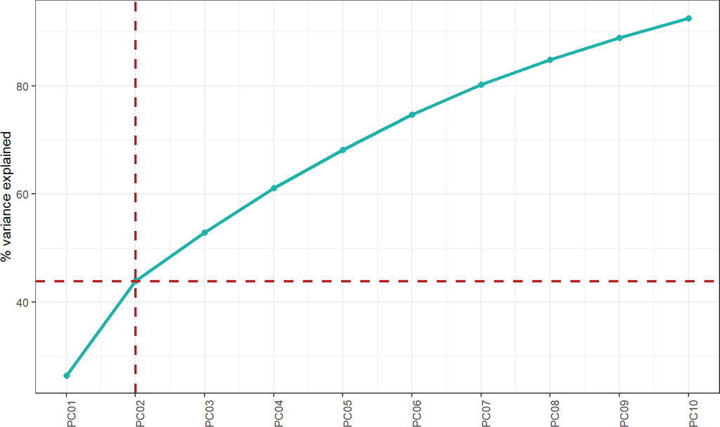

```r
ds.exposome_pca_plot("ds.exposome_pca.Results", set = "variance_explained", method = 1, k = 3, noise = 5)
```

Furthermore, the `ds.exposome_pca_plot` function can plot the correlations betweeen the principal components and the exposures and the association of the phenotypes with the principal components. This two visualizations can be obtained by setting the `set` argument to `"exposures_correlation"` and `"phenotypes_correlation"` respectively.

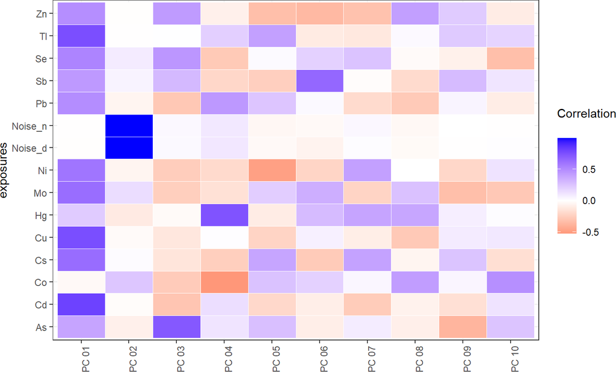

```r
ds.exposome_pca_plot("ds.exposome_pca.Results", set = "exposures_correlation")
```

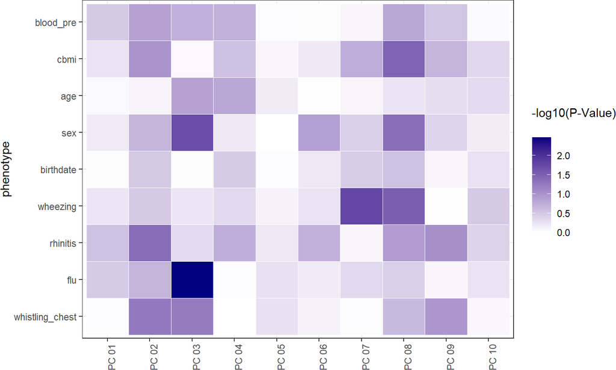

```r
ds.exposome_pca_plot("ds.exposome_pca.Results", set = "phenotypes_correlation")
```

## 1.7 Exposures Correlation

The correlation between exposures, in terms of intra-family and inter-family exposures, is interesting to take into account. The correlation of the exposome can be computed using `ds.correlation`. The correlation could be disclosive, for that reason there’s the argument `fam` to select the families to compute the correlation subsetting the exposome dataset by families, typical complete exposome datasets will fail as the correlation matrix could be disclosive.

```r
ds.correlation("exposome_object")[[1]][[1]]$`Correlation Matrix`[1:5,1:5]
```

```
     [,1] [,2] [,3] [,4] [,5]
[1,]   NA   NA   NA   NA   NA
[2,]   NA   NA   NA   NA   NA
[3,]   NA   NA   NA   NA   NA
[4,]   NA   NA   NA   NA   NA
[5,]   NA   NA   NA   NA   NA
```

```r
ds.correlation("exposome_object")[[1]][[1]]$`Error message`
```

```
[1] "ERROR: The ratio of the number of variables over the number of individual-level records exceeds the allowed threshold, there is a possible risk of disclosure"
```

When subsetting the exposome set by families the correlation succeeds.

```r
ds.correlation("exposome_object", c("Metals", "Noise"))[[1]][[1]]$`Correlation Matrix`[1:5,1:5]
```

```
            [,1]       [,2]        [,3]       [,4]        [,5]
[1,]  1.00000000 0.08897651 -0.12603679  0.1112793 -0.03127031
[2,]  0.08897651 1.00000000  0.10209881  0.5356812  0.84660044
[3,] -0.12603679 0.10209881  1.00000000 -0.5111215 -0.05851681
[4,]  0.11127929 0.53568121 -0.51112146  1.0000000  0.47229280
[5,] -0.03127031 0.84660044 -0.05851681  0.4722928  1.00000000
```

The output from the `ds.correlation` consists of the correlation matrix and a vector that contains the names of exposures and families on the correlation table, this second item is used by the `corPlot` function to display the results of the correlation study.

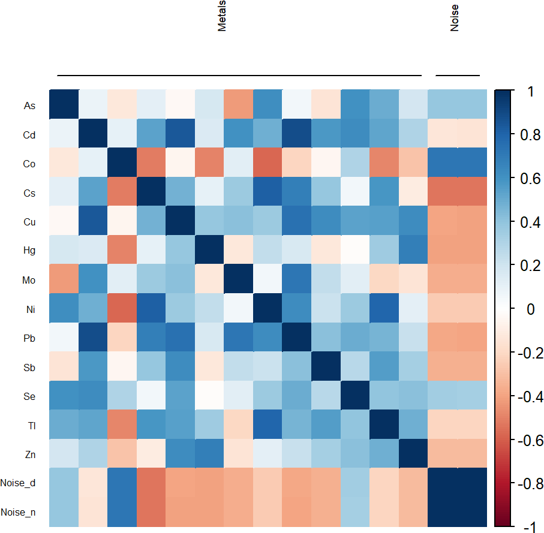

```r
corr_data <- ds.correlation("exposome_object", c("Metals", "Noise"))
corPlot(corr_data)
```

The best option to see the inter-family correlations is the *circos of correlations* while the *matrix of correlations* is a better way for studying the intra-family correlations.

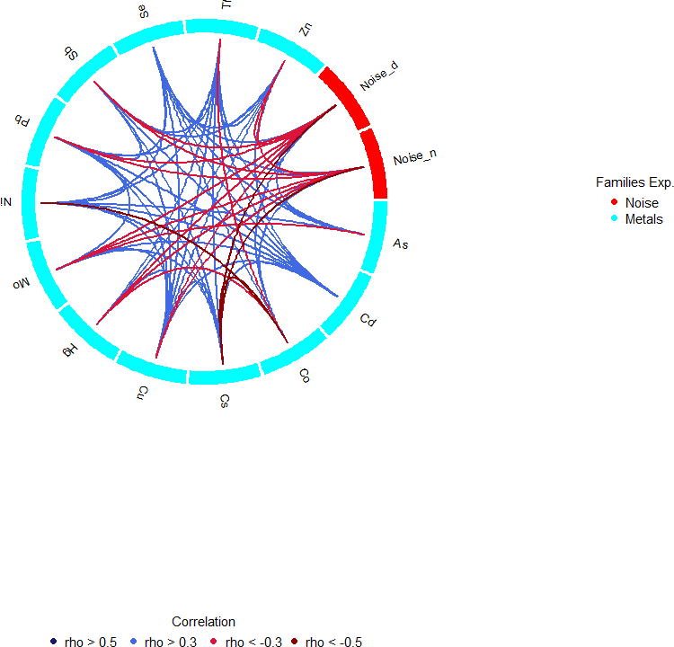

```r
corPlot(corr_data, type = "circos")
```

```r
datashield.logout(conns)
```